# Lab 10 - Vanilla CNN and Fine-Tune VGG16 - for Dogs and Cats Classification

In this lab, we are classifying images of dogs and cats using deep learning methods. We begin by exploring the Dogs vs Cats dataset through exploratory data analysis to understand its characteristics. Then, we train two neural network models: one from scratch, employing a Vanilla CNN architecture, and the other by fine-tuning a pre-trained VGG16 model.

The dataset can be obtained from:

- [Dogs versus Cats](https://www.kaggle.com/c/dogs-vs-cats) - The Kaggle competition

```python
# import Packages
import warnings
warnings.filterwarnings('ignore')

import pandas as pd
from tqdm import tqdm_notebook as tqdm
import matplotlib.image as mpimg
import matplotlib.pyplot as plt
import seaborn as sns
from tensorflow import keras
from tensorflow.keras import layers
from tensorflow.keras.utils import image_dataset_from_directory
from sklearn.metrics import confusion_matrix, classification_report, precision_recall_curve
import numpy as np
import pathlib
```

## Get Data

```python
data_folder = pathlib.Path('data/kaggle_dogs_vs_cats_sub')
```

## EDA

Reference: [Kaggle - TATERTOTS](https://www.kaggle.com/code/srispirit/eda-keras-cnn-tutorial-cats-vs-dogs)

### Categorizing into 2 Classes

```python
filenames = os.listdir('data/kaggle_dogs_vs_cats/train')
labels = [str(x)[:3] for x in filenames]
train_df = pd.DataFrame({'filename': filenames, 'label': labels})
train_df['label'] = train_df['label'].map({'dog': '1', 'cat':'0'})
train_df.head()
```

|  | filename | label |
| --- | --- | --- |
| 0 | cat.0.jpg | 0 |
| 1 | cat.1.jpg | 0 |
| 2 | cat.10.jpg | 0 |
| 3 | cat.100.jpg | 0 |
| 4 | cat.1000.jpg | 0 |

### Displaying Sample Images for Each Class

```
The data has 2 unique classes
```

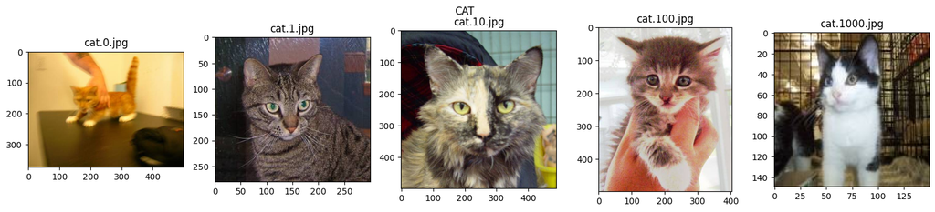

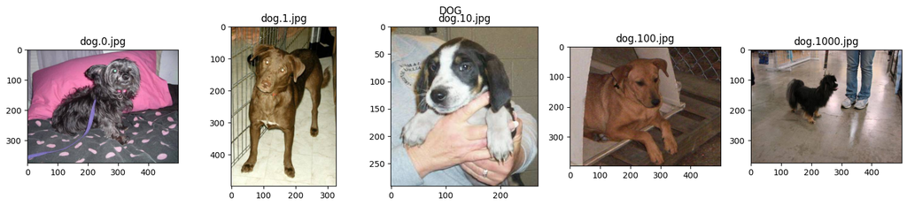

```python
print(f"The data has {train_df['label'].nunique()} unique classes")

for lab in train_df['label'].unique():
    #Subset to just that target
    label_df = train_df[train_df['label']==lab].reset_index()
    cols = 5
    rows = 1
    fig = plt.figure(figsize = (4*cols - 1, 4.5*rows - 1))
    for c in range(cols):
        for r in range(rows):
            ax = fig.add_subplot(rows, cols, c*rows + r + 1)
            img = mpimg.imread('data/kaggle_dogs_vs_cats/train/'+label_df['filename'][c+r])
            ax.imshow(img)
            ax.set_title(str(label_df['filename'][c+r]))
    fig.suptitle(str(label_df['filename'][c+r][:3].upper()))
    plt.show()
    plt.close()
```

### Getting Dimension of Each Class

```python
dims_dict = {'image': [], 'width': [], 'height': [], 'channels': []}
for i in tqdm(range(len(train_df))):
    dims = mpimg.imread('data/kaggle_dogs_vs_cats/train/'+train_df['filename'][i]).shape
    dims_dict['image'].append(train_df['filename'][i])
    dims_dict['height'].append(dims[0])
    dims_dict['width'].append(dims[1])
    dims_dict['channels'].append(dims[2])

dims_df = pd.DataFrame(dims_dict)
dims_df['label'] = dims_df['image'].apply(lambda x: x[:3])
dims_df.head(3)
```

|  | image | width | height | channels | label |
| --- | --- | --- | --- | --- | --- |
| 0 | cat.0.jpg | 500 | 374 | 3 | cat |
| 1 | cat.1.jpg | 300 | 280 | 3 | cat |
| 2 | cat.10.jpg | 489 | 499 | 3 | cat |

### Plotting the Dimensions of Each Class

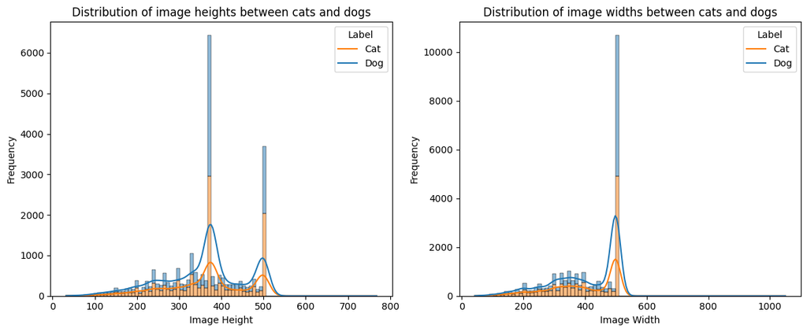

```python
# Create a figure and axes for subplots
fig, axes = plt.subplots(1, 2, figsize=(12, 5))

# Plotting the distribution of image heights for dogs and cats
sns.histplot(data=dims_df, x='height', hue='label', multiple='stack', kde=True, ax=axes[0])
axes[0].set_title('Distribution of image heights between cats and dogs')
axes[0].set_xlabel('Image Height')
axes[0].set_ylabel('Frequency')
axes[0].legend(title='Label', labels=['Cat', 'Dog'])

# Plotting the distribution of image widths for dogs and cats
sns.histplot(data=dims_df, x='width', hue='label', multiple='stack', kde=True, ax=axes[1])
axes[1].set_title('Distribution of image widths between cats and dogs')
axes[1].set_xlabel('Image Width')
axes[1].set_ylabel('Frequency')
axes[1].legend(title='Label', labels=['Cat', 'Dog'])

# Adjust layout to prevent overlap
plt.tight_layout()
plt.show()
```